# Project 1

Tony Nguyen

2019-02-20

Abstract

This project is all about analysing the SWDEFECTS file using R and probability theory. Here we are investigating data from the software defects file, SWDEFECTS.csv. We start by summarizing the data and then making a formula of how to calculate efficiency in catching defects. We then make a bar graph of the defects found. Afterwards we test the Accuracy, Detection Rate, False Alarm Rate, and Precision of capturing these defects. We then make a bar graph to better visual the process.

# 1 Introduction to the data

## 1.2 Summary Table

Creating the summary table (TABLE SIA3.2) found on page 125 in MS book.

```r
summary <- matrix(c("", "No", "Yes", "", "False", "a", "c", "", "True", "b", "d", ""), ncol = 3)

colnames(summary) <- c("", "Module", "Has Defects")
rownames(summary) <- c("", "Algorithm", "Predicts", "Defects")
summary.table <- as.table(summary)
summary.table
```

```
##               Module Has Defects
##               False  True
## Algorithm No  a      b
## Predicts  Yes c      d
## Defects
```

1. Accuracy
2. Detection rate
3. False alarm rate
4. Precision

Latex Example: See (http://www.stat.cmu.edu/~cshalizi/rmarkdown/#elements-of-math-mode)

$$\begin{eqnarray}
P(|X-\mu| > k) & = & P(|X-\mu|^2 > k^2)\\
& \leq & \frac{\mathbb{E}\left[|X-\mu|^2\right]}{k^2}\\
& \leq & \frac{\mathrm{Var}[X]}{k^2}
\end{eqnarray}$$

# 2 R functions

```r
acc=function(a,b,c,d)
{
  (a + d)/(a + b + c + d)
}
```

```r
detect=function(b,d)
{
  (d)/(b + d)
}
```

```r
falarm=function(a,c)
{
  (c)/(a + c)
}
```

```r
prec=function(c,d)
{
  (d)/(c + d)
}
```

# 3 Create the tables in Figure SIA3.1

Making the software defect table and a bar graph of it.

```r
softwareDefect <- matrix(c("LOC > 50", "v(g) > 10)", "ev(g) >= 14.5", "iv(g) >= 9.2", "LOC = lines of code", "v(g) = number of linearly independent paths", "ev(g) = number of subflow graphs with D-structured primes", "iv(g) = cyclomatic complexity of module's reduced flow graph"), ncol = 2)

colnames(softwareDefect) <- c("Deflects Algorithm", "Definitions")

rownames(softwareDefect) <- c("Lines of code", "Cyclomatic complexity", "Essential complexity", "Design complexity")

softwareDefect.table <- as.table(softwareDefect)
softwareDefect.table
```

```
##                       Deflects Algorithm
## Lines of code         LOC > 50
## Cyclomatic complexity v(g) > 10)
## Essential complexity  ev(g) >= 14.5
## Design complexity     iv(g) >= 9.2
##                       Definitions
## Lines of code         LOC = lines of code
## Cyclomatic complexity v(g) = number of linearly independent paths
## Essential complexity  ev(g) = number of subflow graphs with D-structured primes
## Design complexity     iv(g) = cyclomatic complexity of module's reduced flow graph
```

```r
swd = read.csv("SWDEFECTS.csv")
head(swd)
```

|  | Mloc | Mvg | Mevg | Mivg | Hn | Hvol | Hpgmlen | Hdiff | Hintell | Heffort | Hb | Htime | Hloc | Hcomm | Hblank | loc.comm | uniOp | uniOpnd | totOp | totOpnd | brnchcnt | defect | predict.vg.10 | predict.evg.14.5 | predict.ivg.9.2 | predict.loc.50 |
| --- | --- | --- | --- | --- | --- | --- | --- | --- | --- | --- | --- | --- | --- | --- | --- | --- | --- | --- | --- | --- | --- | --- | --- | --- | --- | --- |
| 1 | 1.1 | 1.4 | 1.4 | 1.4 | 1.3 | 1.3 | 1.30 | 1.30 | 1.30 | 1 | 1.30 | 1 | 2 | 2 | 2 | 2 | 1.2 | 1.2 | 1.2 | 1.2 | 1.4 | FALSE | no | no | no | no |
| 2 | 1.0 | 1.0 | 1.0 | 1.0 | 1.0 | 1.0 | 1.00 | 1.00 | 1.00 | 1 | 1.00 | 1 | 1 | 1 | 1 | 1 | 1.0 | 1.0 | 1.0 | 1.0 | 1.0 | TRUE | no | no | no | no |
| 3 | 24.0 | 5.0 | 1.0 | 3.0 | 63.0 | 309.1 | 0.11 | 9.50 | 32.54 | 2937 | 0.10 | 163 | 1 | 0 | 6 | 0 | 15.0 | 15.0 | 44.0 | 19.0 | 9.0 | FALSE | no | no | no | no |
| 4 | 20.0 | 4.0 | 4.0 | 2.0 | 47.0 | 215.5 | 0.06 | 16.00 | 13.47 | 3448 | 0.07 | 192 | 0 | 0 | 3 | 0 | 16.0 | 8.0 | 31.0 | 16.0 | 7.0 | FALSE | no | no | no | no |
| 5 | 24.0 | 6.0 | 6.0 | 2.0 | 72.0 | 346.1 | 0.06 | 17.33 | 19.97 | 6000 | 0.12 | 333 | 0 | 0 | 3 | 0 | 16.0 | 12.0 | 46.0 | 26.0 | 11.0 | FALSE | no | no | no | no |
| 6 | 24.0 | 6.0 | 6.0 | 2.0 | 72.0 | 346.1 | 0.06 | 17.33 | 19.97 | 6000 | 0.12 | 333 | 0 | 0 | 3 | 0 | 16.0 | 12.0 | 46.0 | 26.0 | 11.0 | FALSE | no | no | no | no |

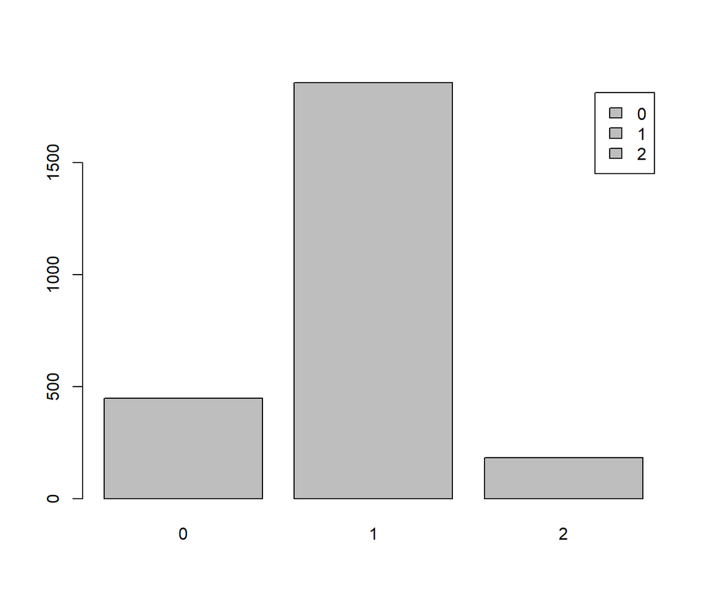

```r
tab1 = with(swd, table(c(predict.loc.50, predict.vg.10, predict.evg.14.5, predict.ivg.9.2, defect)))
barplot(tab1, beside=TRUE, leg=TRUE)
```

```r
tab2 = addmargins(tab1)
tab2
```

```
##
##    0    1    2  Sum
##  449 1858  183 2490
```

# 4 TABLE SIA3.3 on page 127 in the MS Statistics book.

Below we will create table SIA3.3 using the mybar() function. We will call the table tab3.

> 1. tab ( this will be a n by m table) - like `tab3`
> 2. acc ( accuracy of the decimal output ) – like `acc=4` for example

SIA3.3 Table

```r
tab3 <- matrix(c(0.843, 0.825, 0.990, 0.869, 0.408, 0.286, 0.041, 0.224, 0.091, 0.116, 0.018, 0.060, 0.333, 0.212, 0.200, 0.289), ncol=4)

colnames(tab3) <- c('Accuracy', 'Detection Rate', 'False Alarm Rate', 'Precision')
rownames(tab3) <- c("Lines of code", "Cyclomatic complexity", "Essential complexity", "Design complexity")

tab3.table <- as.table(tab3)
tab3.table
```

```
##                       Accuracy Detection Rate False Alarm Rate Precision
## Lines of code            0.843          0.408            0.091     0.333
## Cyclomatic complexity    0.825          0.286            0.116     0.212
## Essential complexity     0.990          0.041            0.018     0.200
## Design complexity        0.869          0.224            0.060     0.289
```

The function will need to create two things

> 1. A barplot of the table
> 2. Commandline output in the form of a list containing the table

mybar function

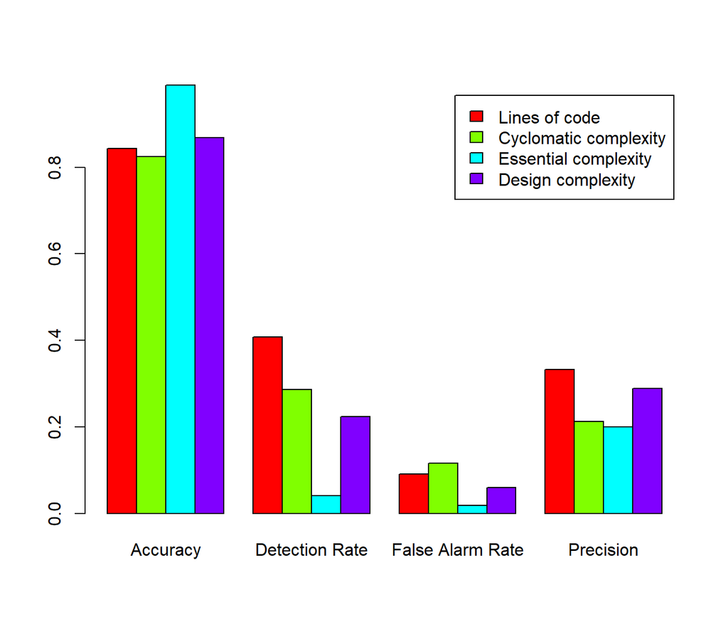

```r
mybar=function(tab, acc)
{
  barplot(round(tab, acc), col = rainbow(acc), legend = rownames(tab), beside = TRUE)
}

mybar(tab = tab3, acc = 4)
```